# Homework 2

## Question 1

### a)

```r
#include=FALSE doesn't write the code on your document
#eval=TRUE runs the code during knitting process
require(data.table)
require(anytime)
require (MASS)
```

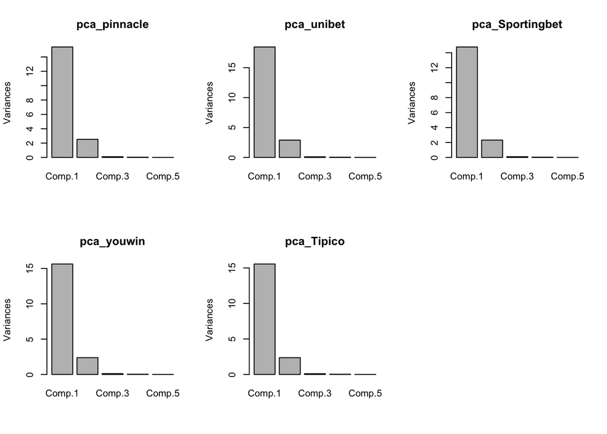

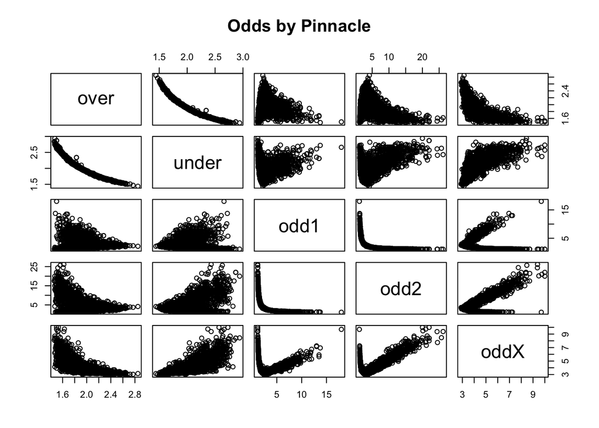

```r
matches=readRDS ('/Users/esinakgul/Documents/BOUN/4-1/IE 582/HOMEWORK/Homework 1/df9b1196-e3cf-4cc7-9159-f236fe738215_matches.rds')

odds=readRDS ('/Users/esinakgul/Documents/BOUN/4-1/IE 582/HOMEWORK/Homework 1/df9b1196-e3cf-4cc7-9159-f236fe738215_odd_details.rds')

matches[,c("HomeGoals","AwayGoals"):=tstrsplit(score,':')]
matches$HomeGoals=as.numeric(matches$HomeGoals)
matches[,AwayGoals:=as.numeric(AwayGoals)]

matches[,TotalGoals:=HomeGoals+AwayGoals]
matches[,IsOver:=0]
matches[TotalGoals>2,IsOver:=1]

matches=matches[complete.cases(matches)]
pinnacle_odds=odds[bookmaker=='Pinnacle']
pinnacle_odds_final=pinnacle_odds[,list(final_odd=odd[.N]),
                            by=list(matchId,betType, oddtype,bookmaker, totalhandicap)]

pinnacle_odd1=pinnacle_odds_final[oddtype=='odd1']
setnames(pinnacle_odd1, old=c("final_odd"), new=c("odd1"))

pinnacle_oddX=pinnacle_odds_final[oddtype=='oddX']
setnames(pinnacle_oddX, old=c("final_odd"), new=c("oddX"))

pinnacle_odd2=pinnacle_odds_final[oddtype=='odd2']
setnames(pinnacle_odd2, old=c("final_odd"), new=c("odd2"))

pinnacle_over=pinnacle_odds_final[oddtype=='over']
pinnacle_over=pinnacle_over[totalhandicap=='2.5']
setnames(pinnacle_over, old=c("final_odd"), new=c("over"))

pinnacle_under=pinnacle_odds_final[oddtype=='under']
pinnacle_under=pinnacle_under[totalhandicap=='2.5']
setnames(pinnacle_under, old=c("final_odd"), new=c("under"))

merged_odds=merge(pinnacle_over,pinnacle_under[,matchId,under], by='matchId')
merged_odds=merge(merged_odds, pinnacle_odd1[,matchId, odd1], by='matchId')
merged_odds=merge(merged_odds, pinnacle_odd2[,matchId, odd2], by='matchId')
merged_odds=merge(merged_odds, pinnacle_oddX[,matchId, oddX], by='matchId')

merged_odds=merged_odds[,oddtype:=NULL]

merged_odds_matches=merge(matches,merged_odds, by='matchId')
merged_odds_matches[,leagueId:=NULL]
merged_odds_matches[,score:=NULL]
merged_odds_matches[,type:=NULL]
pca_data=merged_odds_matches[,c(12,13,14,15,16)]

par(mfrow=c(2,3))

pca_pinnacle=princomp(pca_data)
plot(pca_pinnacle)



#for Unibet
unibet_odds=odds[bookmaker=='Unibet']
unibet_odds_final=unibet_odds[,list(final_odd=odd[.N]),
                                  by=list(matchId,betType, oddtype,bookmaker, totalhandicap)]

unibet_odd1=unibet_odds_final[oddtype=='odd1']
setnames(unibet_odd1, old=c("final_odd"), new=c("odd1"))

unibet_oddX=unibet_odds_final[oddtype=='oddX']
setnames(unibet_oddX, old=c("final_odd"), new=c("oddX"))

unibet_odd2=unibet_odds_final[oddtype=='odd2']
setnames(unibet_odd2, old=c("final_odd"), new=c("odd2"))

unibet_over=unibet_odds_final[oddtype=='over']
unibet_over=unibet_over[totalhandicap=='2.5']
setnames(unibet_over, old=c("final_odd"), new=c("over"))

unibet_under=unibet_odds_final[oddtype=='under']
unibet_under=unibet_under[totalhandicap=='2.5']
setnames(unibet_under, old=c("final_odd"), new=c("under"))

merged_odds_unibet=merge(unibet_over,unibet_under[,matchId,under], by='matchId')
merged_odds_unibet=merge(merged_odds_unibet, unibet_odd1[,matchId, odd1], by='matchId')
merged_odds_unibet=merge(merged_odds_unibet, unibet_odd2[,matchId, odd2], by='matchId')
merged_odds_unibet=merge(merged_odds_unibet, unibet_oddX[,matchId, oddX], by='matchId')

merged_odds_unibet=merged_odds_unibet[,oddtype:=NULL]

merged_odds_matches_unibet=merge(matches,merged_odds_unibet, by='matchId')
merged_odds_matches_unibet[,leagueId:=NULL]
merged_odds_matches_unibet[,score:=NULL]
merged_odds_matches_unibet[,type:=NULL]
pca_data_unibet=merged_odds_matches_unibet[,c(12,13,14,15,16)]


pca_unibet=princomp(pca_data_unibet)
plot(pca_unibet)


#Sportingbet
Sportingbet_odds=odds[bookmaker=='Sportingbet']
Sportingbet_odds_final=Sportingbet_odds[,list(final_odd=odd[.N]),
                              by=list(matchId,betType, oddtype,bookmaker, totalhandicap)]

Sportingbet_odd1=Sportingbet_odds_final[oddtype=='odd1']
setnames(Sportingbet_odd1, old=c("final_odd"), new=c("odd1"))

Sportingbet_oddX=Sportingbet_odds_final[oddtype=='oddX']
setnames(Sportingbet_oddX, old=c("final_odd"), new=c("oddX"))

Sportingbet_odd2=Sportingbet_odds_final[oddtype=='odd2']
setnames(Sportingbet_odd2, old=c("final_odd"), new=c("odd2"))

Sportingbet_over=Sportingbet_odds_final[oddtype=='over']
Sportingbet_over=Sportingbet_over[totalhandicap=='2.5']
setnames(Sportingbet_over, old=c("final_odd"), new=c("over"))

Sportingbet_under=Sportingbet_odds_final[oddtype=='under']
Sportingbet_under=Sportingbet_under[totalhandicap=='2.5']
setnames(Sportingbet_under, old=c("final_odd"), new=c("under"))

merged_odds_Sportingbet=merge(Sportingbet_over,Sportingbet_under[,matchId,under], by='matchId')
merged_odds_Sportingbet=merge(merged_odds_Sportingbet, Sportingbet_odd1[,matchId, odd1], by='matchId')
merged_odds_Sportingbet=merge(merged_odds_Sportingbet, Sportingbet_odd2[,matchId, odd2], by='matchId')
merged_odds_Sportingbet=merge(merged_odds_Sportingbet, Sportingbet_oddX[,matchId, oddX], by='matchId')

merged_odds_Sportingbet=merged_odds_Sportingbet[,oddtype:=NULL]

merged_odds_matches_Sportingbet=merge(matches,merged_odds_Sportingbet, by='matchId')
merged_odds_matches_Sportingbet[,leagueId:=NULL]
merged_odds_matches_Sportingbet[,score:=NULL]
merged_odds_matches_Sportingbet[,type:=NULL]
merged_odds_matches_Sportingbet=unique(merged_odds_matches_Sportingbet)
pca_data_Sportingbet=merged_odds_matches_Sportingbet[,c(12,13,14,15,16)]


pca_Sportingbet=princomp(pca_data_Sportingbet)
plot(pca_Sportingbet)


#youwin
youwin_odds=odds[bookmaker=='youwin']
youwin_odds_final=youwin_odds[,list(final_odd=odd[.N]),
                                        by=list(matchId,betType, oddtype,bookmaker, totalhandicap)]

youwin_odd1=youwin_odds_final[oddtype=='odd1']
setnames(youwin_odd1, old=c("final_odd"), new=c("odd1"))

youwin_oddX=youwin_odds_final[oddtype=='oddX']
setnames(youwin_oddX, old=c("final_odd"), new=c("oddX"))

youwin_odd2=youwin_odds_final[oddtype=='odd2']
setnames(youwin_odd2, old=c("final_odd"), new=c("odd2"))

youwin_over=youwin_odds_final[oddtype=='over']
youwin_over=youwin_over[totalhandicap=='2.5']
setnames(youwin_over, old=c("final_odd"), new=c("over"))

youwin_under=youwin_odds_final[oddtype=='under']
youwin_under=youwin_under[totalhandicap=='2.5']
setnames(youwin_under, old=c("final_odd"), new=c("under"))

merged_odds_youwin=merge(youwin_over,youwin_under[,matchId,under], by='matchId')
merged_odds_youwin=merge(merged_odds_youwin, youwin_odd1[,matchId, odd1], by='matchId')
merged_odds_youwin=merge(merged_odds_youwin, youwin_odd2[,matchId, odd2], by='matchId')
merged_odds_youwin=merge(merged_odds_youwin, youwin_oddX[,matchId, oddX], by='matchId')

merged_odds_youwin=merged_odds_youwin[,oddtype:=NULL]

merged_odds_matches_youwin=merge(matches,merged_odds_youwin, by='matchId')
merged_odds_matches_youwin[,leagueId:=NULL]
merged_odds_matches_youwin[,score:=NULL]
merged_odds_matches_youwin[,type:=NULL]
merged_odds_matches_youwin=unique(merged_odds_matches_youwin)
pca_data_youwin=merged_odds_matches_youwin[,c(12,13,14,15,16)]


pca_youwin=princomp(pca_data_youwin)
plot(pca_youwin)

#Tipico
Tipico_odds=odds[bookmaker=='Tipico']
Tipico_odds_final=Tipico_odds[,list(final_odd=odd[.N]),
                              by=list(matchId,betType, oddtype,bookmaker, totalhandicap)]

Tipico_odd1=Tipico_odds_final[oddtype=='odd1']
setnames(Tipico_odd1, old=c("final_odd"), new=c("odd1"))

Tipico_oddX=Tipico_odds_final[oddtype=='oddX']
setnames(Tipico_oddX, old=c("final_odd"), new=c("oddX"))

Tipico_odd2=Tipico_odds_final[oddtype=='odd2']
setnames(Tipico_odd2, old=c("final_odd"), new=c("odd2"))

Tipico_over=Tipico_odds_final[oddtype=='over']
Tipico_over=Tipico_over[totalhandicap=='2.5']
setnames(Tipico_over, old=c("final_odd"), new=c("over"))

Tipico_under=Tipico_odds_final[oddtype=='under']
Tipico_under=Tipico_under[totalhandicap=='2.5']
setnames(Tipico_under, old=c("final_odd"), new=c("under"))

merged_odds_Tipico=merge(Tipico_over,Tipico_under[,matchId,under], by='matchId')
merged_odds_Tipico=merge(merged_odds_Tipico, Tipico_odd1[,matchId, odd1], by='matchId')
merged_odds_Tipico=merge(merged_odds_Tipico,Tipico_odd2[,matchId, odd2], by='matchId')
merged_odds_Tipico=merge(merged_odds_Tipico, Tipico_oddX[,matchId, oddX], by='matchId')

merged_odds_Tipico=merged_odds_Tipico[,oddtype:=NULL]

merged_odds_matches_Tipico=merge(matches,merged_odds_Tipico, by='matchId')
merged_odds_matches_Tipico[,leagueId:=NULL]
merged_odds_matches_Tipico[,score:=NULL]
merged_odds_matches_Tipico[,type:=NULL]
merged_odds_matches_Tipico=unique(merged_odds_matches_Tipico)
pca_data_Tipico=merged_odds_matches_Tipico[,c(12,13,14,15,16)]
#Pinnacle

pca_Tipico=princomp(pca_data_Tipico)
plot(pca_Tipico)

#end
#Pinnacle
names.arg=c("Over Odds","Under Odds","Winning Odd","Losing Odd","Tie Odd")
plot(pca_data, main="Odds by Pinnacle")
```

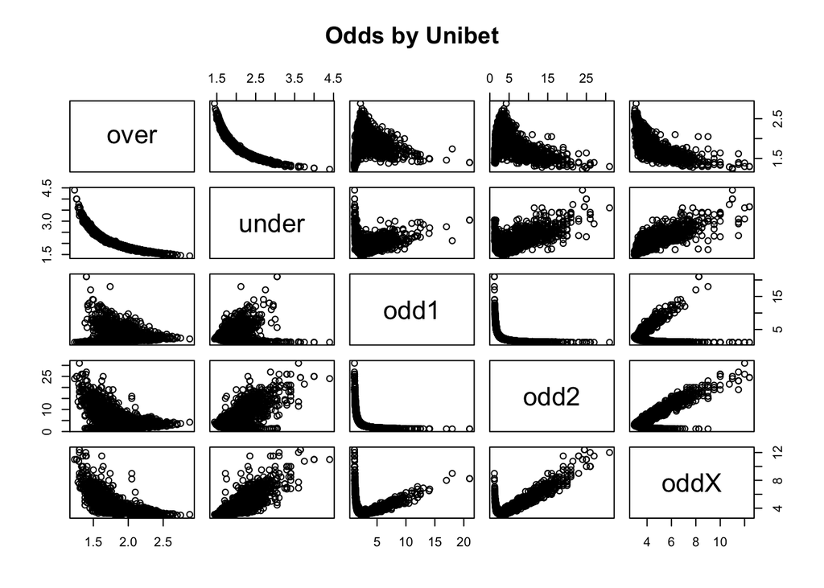

```r
plot(pca_data_unibet,main="Odds by Unibet")
```

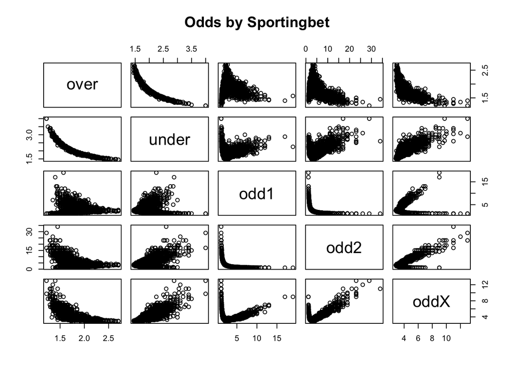

```r
plot(pca_data_Sportingbet,main="Odds by Sportingbet")
```

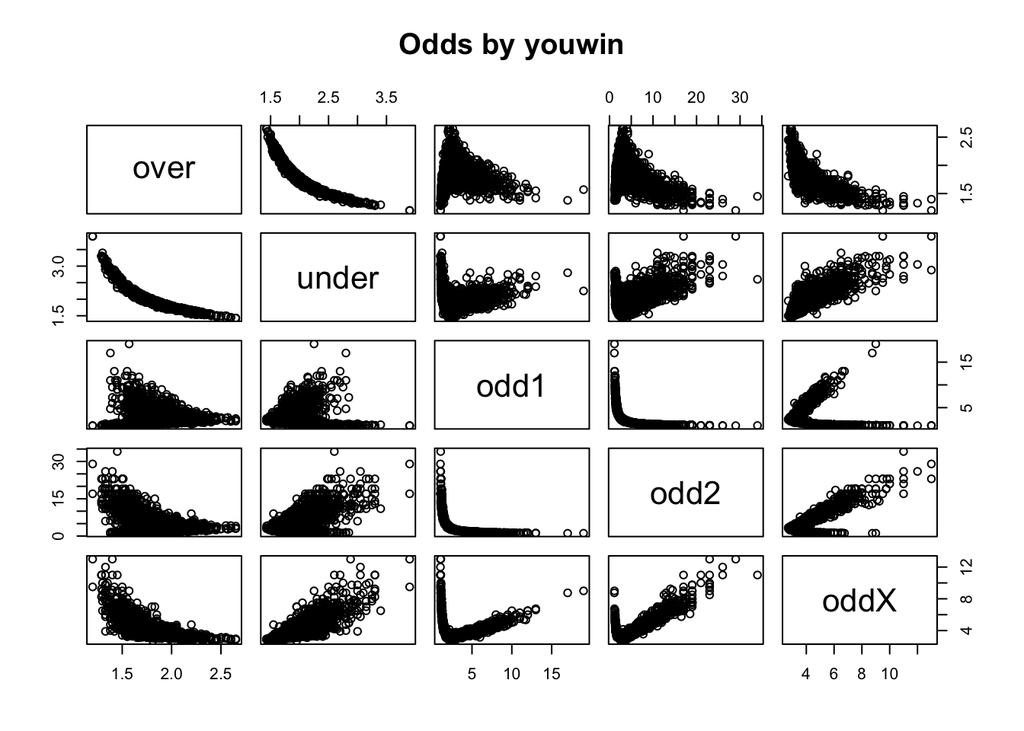

```r
plot(pca_data_youwin,main="Odds by youwin")
```

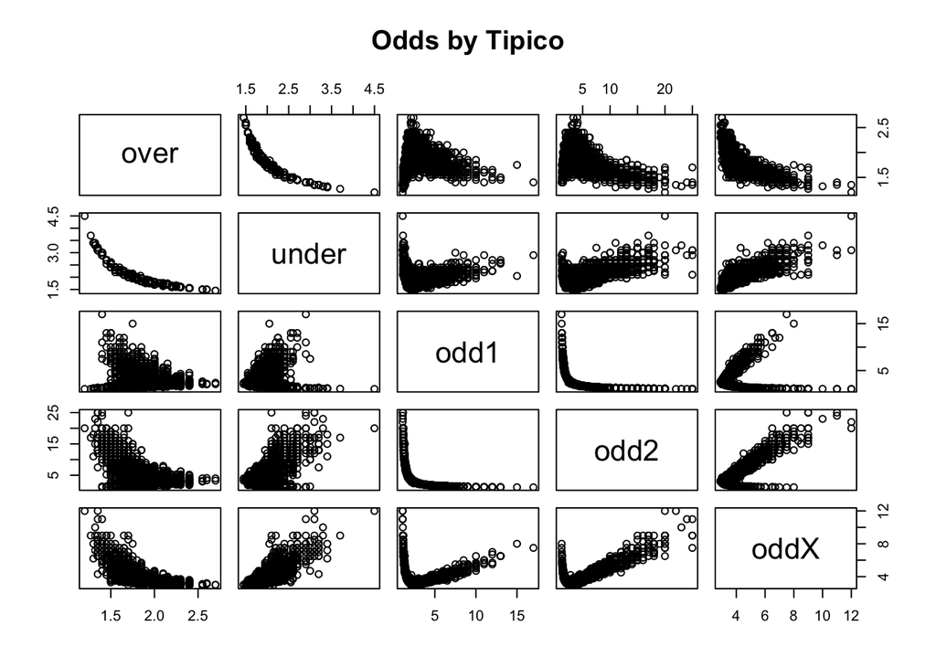

```r
plot(pca_data_Tipico,main="Odds by Tipico")
```

The above plots presents visualization of odds given by 5 different bookmakers for 5 different cases for 2 different types of bet. The bar charts indicates pca of 5 different bookmakers for under odds, over odd, winning odds, losing odds, and tie odds respectively. Wee see tthat there are variations among bookmakers. Pinnacle and Sportingbet have the lowest variances whereas, unibet, youwin and Tipico has a greater variance. However, all of the bookmakers show a similar trend which is decreasing variance when from comp.1 to comp.5. This means that their final odds given for five different oddtypes show a similar behaviour. 5x5 graphs sets are the representation of finall odds for each bookmaker. Unfortunately, I counldn’t perform MDS, so part I couldn’t do part b and c.

## Question 2

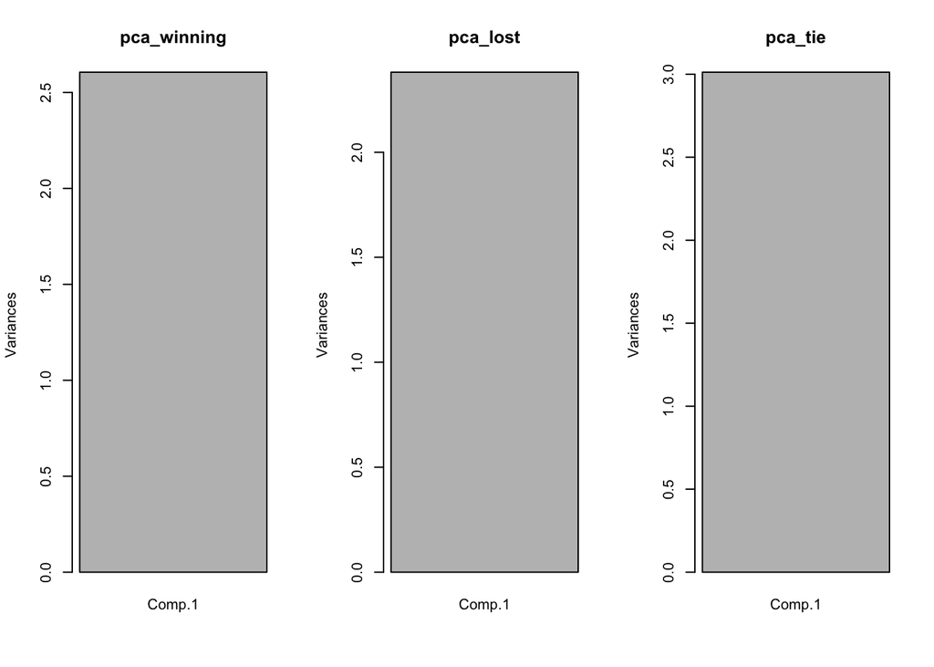

```r
#include=FALSE doesn't write the code on your document
#eval=TRUE runs the code during knitting process
require(data.table)
require(anytime)
require (MASS)
matches=readRDS ('/Users/esinakgul/Documents/BOUN/4-1/IE 582/HOMEWORK/Homework 1/df9b1196-e3cf-4cc7-9159-f236fe738215_matches.rds')

matches[,c("HomeGoals","AwayGoals"):=tstrsplit(score,':')]
matches$HomeGoals=as.numeric(matches$HomeGoals)
matches[,AwayGoals:=as.numeric(AwayGoals)]

matches=matches[complete.cases(matches)]

matches=matches[,results:='0']



matches=matches[,TotalGoals:=HomeGoals+AwayGoals]

matches[HomeGoals>AwayGoals, results:='Win']
matches[HomeGoals<AwayGoals, results:='Lose']
matches[HomeGoals==AwayGoals, results:='Tie']


tiegames=matches[results=='Tie']
setnames(tiegames, old=c("TotalGoals"), new=c("TotalGoals_TieGame"))
tiegames=tiegames[,index:=1:791]
Lostgames=matches[results=='Lose']
setnames(Lostgames, old=c("TotalGoals"), new=c("TotalGoals_LostGame"))
Lostgames=Lostgames[,index:=1:918]
Wongames=matches[results=='Win']
setnames(Wongames, old=c("TotalGoals"), new=c("TotalGoals_WonGame"))
Wongames=Wongames[,index:=1:1420]


par(mfrow=c(1,3))
single_winning=Wongames[,TotalGoals_WonGame]
pca_winning=princomp(single_winning)
plot(pca_winning)

single_lost=Lostgames[,TotalGoals_LostGame]
pca_lost=princomp(single_lost)
plot(pca_lost)

single_tie=tiegames[,TotalGoals_TieGame]
pca_tie=princomp(single_tie)
plot(pca_tie)
```

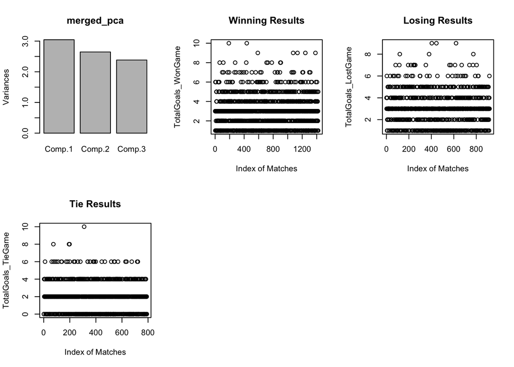

```r
winning_results=Wongames[,TotalGoals_WonGame,index]
losing_results=Lostgames[,TotalGoals_LostGame,index]
tie_results=tiegames[,TotalGoals_TieGame,index]

merged_matches=merge(winning_results,losing_results, by='index')
merged_matches=merge(merged_matches, tie_results, by='index')
merged_matches=merged_matches[,index:=NULL]
merged_pca=princomp(merged_matches)
par(mfrow=c(2,3))
plot(merged_pca)


plot(winning_results, main="Winning Results", xlab="Index of Matches")
plot(losing_results,main="Losing Results", xlab="Index of Matches")
plot(tie_results,xlab="Index of Matches", main="Tie Results")
```

The above bar graphs represents pca for the match result of win, loss and tie for the home team. First of all single pcas are performed since the size of the sets are not equal. Alltough pcas of won and lost matches have almost the same variance, tie matches have a greater variance. Next, I combined the results to see how pca changes with the number of data. Winning matches were the ones with the greates number of data. So the reduction in this data set resulted in a great deviation in the pca result. Following that a representation of match numbers according the result is visualized. We see that most of the matches have ended below a total score of 6. However, there are also some matches with a total score of 8 and 10.

## Question 3

```r
require(jpeg)
```

```r
require(rasterImage)
picture=readJPEG('/Users/esinakgul/Documents/BOUN/4-1/IE 582/HOMEWORK/Homework 2/homework.jpeg')

dim(picture)
```

```
## [1] 512 512   3
```

```r
str(picture)
```

```
##  num [1:512, 1:512, 1:3] 0.847 0.843 0.843 0.843 0.839 ...
```

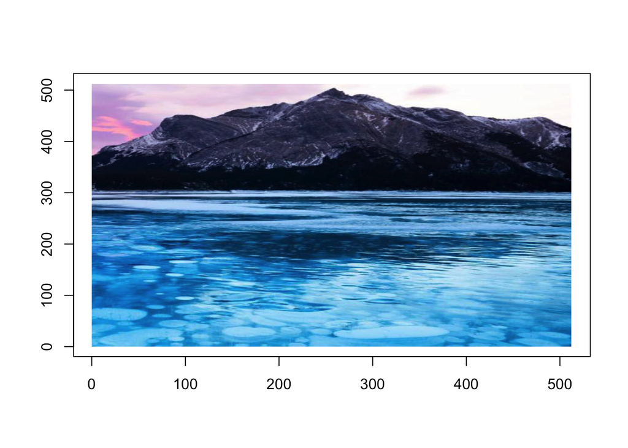

```r
plot(c(1, 512), c(1, 512), type = "n", xlab = "", ylab = "")
rasterImage(picture,xleft=0, ybottom=0, xright=512, ytop=512)
picture_matrix=matrix(picture)
matrix_picture=rasterImage( image=picture , xleft = 1,ybottom = 512, xright = 512, ytop = 1)
```

I was not able to perform task 3 completely. Unfortunately, I had some trouble with my computer.